# 4일차

## Bagging

- 학습 데이터를 복원추출해서 학습을 개별적으로 진행 후 합산

```python
from sklearn.tree import DecisionTreeRegressor as dt

train, test = df[0::2], df[1::2]
train, test = train.reset_index(), test.reset_index()

X_train, y_train = train[features], train[label]
X_test, y_test = test[features], test[label]
```

```python
sampler = [1, 4556, 785, 235]
train.iloc[sampler]
```

|  | index | year | month | day | hour | dayofweek | windforce | discomfort | heat_stroke | regular | casual | group |
| --- | --- | --- | --- | --- | --- | --- | --- | --- | --- | --- | --- | --- |
| 1 | 2 | 2017 | 1 | 1 | 2 | 6 | 0 | 0 | 0 | 38.0 | 19.0 | 0.0 |
| 4556 | 9112 | 2018 | 1 | 13 | 7 | 5 | 0 | 0 | 0 | 43.0 | 0.0 | 0.0 |
| 785 | 1570 | 2017 | 3 | 15 | 8 | 2 | 0 | 0 | 0 | 376.0 | 17.0 | 0.0 |
| 235 | 470 | 2017 | 1 | 29 | 15 | 6 | 0 | 0 | 0 | 10.0 | 0.0 | 0.0 |

```python
sample_list = []
for i in range(5):
    sample_list.append(i)
sample_list
```

```
[0, 1, 2, 3, 4]
```

```python
from random import randint

sample_list = [randint(0, 5) for i in range(5)] # list comprehension
sample_list
```

```
[2, 5, 3, 4, 4]
```

```python
train.tail()
```

|  | index | year | month | day | hour | dayofweek | windforce | discomfort | heat_stroke | regular | casual | group |
| --- | --- | --- | --- | --- | --- | --- | --- | --- | --- | --- | --- | --- |
| 16047 | 32094 | 2021 | 1 | 31 | 15 | 6 | 0 | 0 | 0 | 2058.0 | 1376.0 | 72.0 |
| 16048 | 32096 | 2021 | 1 | 31 | 17 | 6 | 0 | 0 | 0 | 1890.0 | 1042.0 | 29.0 |
| 16049 | 32098 | 2021 | 1 | 31 | 19 | 6 | 0 | 0 | 0 | 1346.0 | 531.0 | 13.0 |
| 16050 | 32100 | 2021 | 1 | 31 | 21 | 6 | 0 | 0 | 0 | 1229.0 | 594.0 | 13.0 |
| 16051 | 32102 | 2021 | 1 | 31 | 23 | 6 | 0 | 0 | 0 | 496.0 | 192.0 | 6.0 |

```python
sampler = [randint(0, len(train)-1) for i in range(len(train))]
train.iloc[sampler]

# bootstrap
```

|  | index | year | month | day | hour | dayofweek | windforce | discomfort | heat_stroke | regular | casual | group |
| --- | --- | --- | --- | --- | --- | --- | --- | --- | --- | --- | --- | --- |
| 6569 | 13138 | 2018 | 9 | 13 | 4 | 3 | 0 | 0 | 0 | 216.0 | 24.0 | 0.0 |
| 7231 | 14462 | 2018 | 11 | 15 | 8 | 3 | 0 | 0 | 0 | 1622.0 | 64.0 | 0.0 |
| 2900 | 5800 | 2017 | 9 | 1 | 20 | 4 | 0 | 0 | 0 | 1003.0 | 587.0 | 7.0 |
| 8637 | 17274 | 2019 | 4 | 11 | 22 | 3 | 0 | 0 | 0 | 1656.0 | 316.0 | 10.0 |
| 11468 | 22936 | 2020 | 2 | 8 | 23 | 5 | 0 | 0 | 0 | 528.0 | 125.0 | 5.0 |
| ... | ... | ... | ... | ... | ... | ... | ... | ... | ... | ... | ... | ... |
| 15605 | 31210 | 2020 | 12 | 27 | 10 | 6 | 0 | 0 | 0 | 891.0 | 260.0 | 10.0 |
| 8367 | 16734 | 2019 | 2 | 16 | 6 | 5 | 0 | 0 | 0 | 78.0 | 4.0 | 0.0 |
| 10000 | 20000 | 2019 | 10 | 7 | 20 | 0 | 0 | 0 | 0 | 1986.0 | 244.0 | 12.0 |
| 14810 | 29620 | 2020 | 10 | 24 | 23 | 5 | 0 | 0 | 0 | 1616.0 | 565.0 | 16.0 |
| 873 | 1746 | 2017 | 3 | 22 | 12 | 2 | 0 | 0 | 0 | 271.0 | 61.0 | 0.0 |

16052 rows × 12 columns

```python
def bootstrap():
    sampler = [randint(0, len(train)-1) for i in range(len(train))]
    return train.iloc[sampler]

bootstrap()
```

|  | index | year | month | day | hour | dayofweek | windforce | discomfort | heat_stroke | regular | casual | group |
| --- | --- | --- | --- | --- | --- | --- | --- | --- | --- | --- | --- | --- |
| 6187 | 12374 | 2018 | 7 | 22 | 18 | 6 | 0 | 2 | 2 | 968.0 | 232.0 | 12.0 |
| 10990 | 21980 | 2020 | 1 | 1 | 21 | 2 | 0 | 0 | 0 | 635.0 | 129.0 | 3.0 |
| 10605 | 21210 | 2019 | 12 | 2 | 21 | 0 | 0 | 0 | 0 | 1319.0 | 118.0 | 3.0 |
| 14271 | 28542 | 2020 | 9 | 10 | 16 | 3 | 0 | 1 | 1 | 3624.0 | 1455.0 | 52.0 |
| 14534 | 29068 | 2020 | 10 | 2 | 8 | 4 | 0 | 0 | 0 | 1174.0 | 369.0 | 12.0 |
| ... | ... | ... | ... | ... | ... | ... | ... | ... | ... | ... | ... | ... |
| 10852 | 21704 | 2019 | 12 | 22 | 6 | 6 | 0 | 0 | 0 | 174.0 | 15.0 | 1.0 |
| 4275 | 8550 | 2017 | 12 | 21 | 19 | 3 | 0 | 0 | 0 | 327.0 | 27.0 | 1.0 |
| 3137 | 6274 | 2017 | 9 | 21 | 3 | 3 | 0 | 0 | 0 | 176.0 | 79.0 | 0.0 |
| 3972 | 7944 | 2017 | 11 | 28 | 2 | 1 | 0 | 0 | 0 | 156.0 | 32.0 | 1.0 |
| 4869 | 9738 | 2018 | 3 | 14 | 18 | 2 | 0 | 0 | 0 | 1541.0 | 551.0 | 8.0 |

16052 rows × 12 columns

```python
multi_df = [bootstrap() for i in range(100)]
len(multi_df)
```

```
100
```

```python
multi_df[2]

# 각 Data Frame을 가지고 feature, label로 나눠서 학습하면,
# 서로 다른 알고리즘이 100개가 생성
```

|  | index | year | month | day | hour | dayofweek | windforce | discomfort | heat_stroke | regular | casual | group |
| --- | --- | --- | --- | --- | --- | --- | --- | --- | --- | --- | --- | --- |
| 5320 | 10640 | 2018 | 4 | 20 | 18 | 4 | 0 | 0 | 0 | 1787.0 | 478.0 | 3.0 |
| 7801 | 15602 | 2018 | 12 | 31 | 20 | 0 | 0 | 0 | 0 | 425.0 | 47.0 | 2.0 |
| 12287 | 24574 | 2020 | 4 | 12 | 17 | 6 | 0 | 0 | 0 | 2330.0 | 1445.0 | 70.0 |
| 14098 | 28196 | 2020 | 8 | 28 | 21 | 4 | 0 | 1 | 0 | 2875.0 | 1091.0 | 24.0 |
| 11058 | 22116 | 2020 | 1 | 7 | 3 | 1 | 0 | 0 | 0 | 39.0 | 5.0 | 0.0 |
| ... | ... | ... | ... | ... | ... | ... | ... | ... | ... | ... | ... | ... |
| 14929 | 29858 | 2020 | 11 | 3 | 14 | 1 | 1 | 0 | 0 | 2268.0 | 419.0 | 16.0 |
| 11154 | 22308 | 2020 | 1 | 14 | 12 | 1 | 0 | 0 | 0 | 973.0 | 100.0 | 3.0 |
| 340 | 680 | 2017 | 2 | 7 | 0 | 1 | 0 | 0 | 0 | 49.0 | 15.0 | 0.0 |
| 8906 | 17812 | 2019 | 5 | 3 | 20 | 4 | 0 | 0 | 0 | 2497.0 | 935.0 | 56.0 |
| 9686 | 19372 | 2019 | 7 | 25 | 8 | 3 | 0 | 1 | 0 | 2612.0 | 115.0 | 0.0 |

16052 rows × 12 columns

```python
forest = []

for single in multi_df:
    X_single, y_single = single[features], single[label]
    tree = dt()
    tree.fit(X_single, y_single)
    forest.append(tree)
len(forest)
```

```
100
```

```python
forest[4].predict(X_test)
```

```
array([  53.,   16.,   16., ..., 1890., 1346., 1157.])
```

```python
opinions = pd.DataFrame()

i = 0
for single_tree in forest:
    i = i + 1
    opinions[str(i) + 'th_tree_say'] = single_tree.predict(X_test)

opinions.head()
```

|  | 1th_tree_say | 2th_tree_say | 3th_tree_say | 4th_tree_say | 5th_tree_say | 6th_tree_say | 7th_tree_say | 8th_tree_say | 9th_tree_say | 10th_tree_say | ... | 91th_tree_say | 92th_tree_say | 93th_tree_say | 94th_tree_say | 95th_tree_say | 96th_tree_say | 97th_tree_say | 98th_tree_say | 99th_tree_say | 100th_tree_say |
| --- | --- | --- | --- | --- | --- | --- | --- | --- | --- | --- | --- | --- | --- | --- | --- | --- | --- | --- | --- | --- | --- |
| 0 | 34.0 | 46.0 | 63.0 | 54.0 | 53.0 | 80.0 | 24.0 | 80.0 | 63.0 | 63.0 | ... | 34.0 | 34.0 | 67.0 | 46.0 | 63.0 | 80.0 | 22.0 | 31.0 | 63.0 | 63.0 |
| 1 | 16.0 | 16.0 | 16.0 | 16.0 | 16.0 | 16.0 | 29.0 | 16.0 | 18.0 | 16.0 | ... | 20.0 | 16.0 | 38.0 | 38.0 | 16.0 | 16.0 | 16.0 | 20.0 | 16.0 | 22.0 |
| 2 | 19.0 | 4.0 | 16.0 | 16.0 | 16.0 | 16.0 | 28.0 | 20.0 | 23.0 | 16.0 | ... | 20.0 | 16.0 | 28.0 | 33.0 | 4.0 | 19.0 | 20.0 | 33.0 | 19.0 | 16.0 |
| 3 | 27.0 | 45.0 | 23.0 | 34.0 | 24.0 | 23.0 | 24.0 | 34.0 | 34.0 | 23.0 | ... | 34.0 | 23.0 | 34.0 | 27.0 | 24.0 | 34.0 | 24.0 | 34.0 | 24.0 | 23.0 |
| 4 | 45.0 | 45.0 | 45.0 | 54.0 | 45.0 | 45.0 | 45.0 | 54.0 | 54.0 | 45.0 | ... | 47.0 | 47.0 | 45.0 | 47.0 | 47.0 | 54.0 | 45.0 | 45.0 | 45.0 | 45.0 |

5 rows × 100 columns

```python
# 각 tree들의 모든 결과를 합산

opinions.T.mean()

# bagging을 이용해서 간략한 random forest를 만들어봄
# forest를 가지고 이상치를 탐지할 수 있음(MCOD)
```

```
0          52.24
1          21.56
2          20.35
3          31.10
4          48.96
          ...
16046    1924.36
16047    2034.87
16048    1848.91
16049    1273.89
16050     901.80
Length: 16051, dtype: float64
```

```python
y_test
```

```
0          55.0
1          22.0
2          21.0
3          31.0
4          41.0
          ...
16046    1937.0
16047    2135.0
16048    1586.0
16049    1298.0
16050     750.0
Name: regular, Length: 16051, dtype: float64
```

## MCOD

- Monte Carlo Outlier Detection
- opinions에 저장된 값을 예측값이 아니라 오차 값으로 저장
- REF : (2009) A New Strategy of Outlier Detection for QSAR/QSPR

```python
i = 0

error_forest = pd.DataFrame()
for single_tree in forest:
    i = i + 1

    error = (y_test - single_tree.predict(X_test)) ** 2
    error_forest[str(i) + 'th_tree_error'] = error

error_forest.head()
```

|  | 1th_tree_error | 2th_tree_error | 3th_tree_error | 4th_tree_error | 5th_tree_error | 6th_tree_error | 7th_tree_error | 8th_tree_error | 9th_tree_error | 10th_tree_error | ... | 91th_tree_error | 92th_tree_error | 93th_tree_error | 94th_tree_error | 95th_tree_error | 96th_tree_error | 97th_tree_error | 98th_tree_error | 99th_tree_error | 100th_tree_error |
| --- | --- | --- | --- | --- | --- | --- | --- | --- | --- | --- | --- | --- | --- | --- | --- | --- | --- | --- | --- | --- | --- |
| 0 | 441.0 | 81.0 | 64.0 | 1.0 | 4.0 | 625.0 | 961.0 | 625.0 | 64.0 | 64.0 | ... | 441.0 | 441.0 | 144.0 | 81.0 | 64.0 | 625.0 | 1089.0 | 576.0 | 64.0 | 64.0 |
| 1 | 36.0 | 36.0 | 36.0 | 36.0 | 36.0 | 36.0 | 49.0 | 36.0 | 16.0 | 36.0 | ... | 4.0 | 36.0 | 256.0 | 256.0 | 36.0 | 36.0 | 36.0 | 4.0 | 36.0 | 0.0 |
| 2 | 4.0 | 289.0 | 25.0 | 25.0 | 25.0 | 25.0 | 49.0 | 1.0 | 4.0 | 25.0 | ... | 1.0 | 25.0 | 49.0 | 144.0 | 289.0 | 4.0 | 1.0 | 144.0 | 4.0 | 25.0 |
| 3 | 16.0 | 196.0 | 64.0 | 9.0 | 49.0 | 64.0 | 49.0 | 9.0 | 9.0 | 64.0 | ... | 9.0 | 64.0 | 9.0 | 16.0 | 49.0 | 9.0 | 49.0 | 9.0 | 49.0 | 64.0 |
| 4 | 16.0 | 16.0 | 16.0 | 169.0 | 16.0 | 16.0 | 16.0 | 169.0 | 169.0 | 16.0 | ... | 36.0 | 36.0 | 16.0 | 36.0 | 36.0 | 169.0 | 16.0 | 16.0 | 16.0 | 16.0 |

5 rows × 100 columns

```python
error_forest.describe()
```

|  | 1th_tree_error | 2th_tree_error | 3th_tree_error | 4th_tree_error | 5th_tree_error | 6th_tree_error | 7th_tree_error | 8th_tree_error | 9th_tree_error | 10th_tree_error | ... | 91th_tree_error | 92th_tree_error | 93th_tree_error | 94th_tree_error | 95th_tree_error | 96th_tree_error | 97th_tree_error | 98th_tree_error | 99th_tree_error | 100th_tree_error |
| --- | --- | --- | --- | --- | --- | --- | --- | --- | --- | --- | --- | --- | --- | --- | --- | --- | --- | --- | --- | --- | --- |
| count | 1.605100e+04 | 1.605100e+04 | 1.605100e+04 | 1.605100e+04 | 1.605100e+04 | 1.605100e+04 | 1.605100e+04 | 1.605100e+04 | 1.605100e+04 | 1.605100e+04 | ... | 1.605100e+04 | 1.605100e+04 | 1.605100e+04 | 1.605100e+04 | 1.605100e+04 | 1.605100e+04 | 1.605100e+04 | 1.605100e+04 | 1.605100e+04 | 1.605100e+04 |
| mean | 3.078632e+05 | 2.966013e+05 | 2.634003e+05 | 3.041501e+05 | 3.259117e+05 | 3.109835e+05 | 3.055947e+05 | 3.153373e+05 | 2.861894e+05 | 2.608872e+05 | ... | 2.743142e+05 | 2.987019e+05 | 3.068623e+05 | 2.726981e+05 | 2.982502e+05 | 3.273939e+05 | 2.950833e+05 | 3.176750e+05 | 3.030504e+05 | 3.037800e+05 |
| std | 1.656560e+06 | 1.587986e+06 | 1.389265e+06 | 1.587746e+06 | 1.749465e+06 | 1.674351e+06 | 1.744876e+06 | 1.743217e+06 | 1.564671e+06 | 1.338660e+06 | ... | 1.500829e+06 | 1.630153e+06 | 1.666868e+06 | 1.412802e+06 | 1.753926e+06 | 1.776085e+06 | 1.688519e+06 | 1.579414e+06 | 1.591013e+06 | 1.591276e+06 |
| min | 0.000000e+00 | 0.000000e+00 | 0.000000e+00 | 0.000000e+00 | 0.000000e+00 | 0.000000e+00 | 0.000000e+00 | 0.000000e+00 | 0.000000e+00 | 0.000000e+00 | ... | 0.000000e+00 | 0.000000e+00 | 0.000000e+00 | 0.000000e+00 | 0.000000e+00 | 0.000000e+00 | 0.000000e+00 | 0.000000e+00 | 0.000000e+00 | 0.000000e+00 |
| 25% | 6.760000e+02 | 6.250000e+02 | 6.250000e+02 | 6.760000e+02 | 6.250000e+02 | 6.250000e+02 | 7.290000e+02 | 6.250000e+02 | 6.250000e+02 | 6.760000e+02 | ... | 6.250000e+02 | 6.760000e+02 | 6.250000e+02 | 6.760000e+02 | 6.760000e+02 | 6.760000e+02 | 6.250000e+02 | 6.760000e+02 | 6.760000e+02 | 6.250000e+02 |
| 50% | 7.569000e+03 | 7.225000e+03 | 7.569000e+03 | 7.225000e+03 | 7.396000e+03 | 7.569000e+03 | 7.569000e+03 | 7.056000e+03 | 7.569000e+03 | 7.396000e+03 | ... | 6.889000e+03 | 7.744000e+03 | 6.889000e+03 | 7.396000e+03 | 7.225000e+03 | 7.396000e+03 | 7.225000e+03 | 7.396000e+03 | 7.569000e+03 | 7.396000e+03 |
| 75% | 6.200100e+04 | 6.350400e+04 | 6.400900e+04 | 6.300100e+04 | 5.953600e+04 | 6.250000e+04 | 5.904900e+04 | 5.953600e+04 | 6.150400e+04 | 6.051600e+04 | ... | 5.475600e+04 | 6.604900e+04 | 6.051600e+04 | 6.076250e+04 | 5.760000e+04 | 6.350400e+04 | 6.027050e+04 | 5.953600e+04 | 6.451600e+04 | 6.200100e+04 |
| max | 4.197744e+07 | 6.606438e+07 | 5.516033e+07 | 5.541314e+07 | 6.606438e+07 | 6.606438e+07 | 6.606438e+07 | 6.606438e+07 | 5.843074e+07 | 4.072992e+07 | ... | 6.606438e+07 | 4.902800e+07 | 6.765062e+07 | 3.403556e+07 | 6.347309e+07 | 6.765062e+07 | 6.347309e+07 | 4.393038e+07 | 3.673572e+07 | 4.325693e+07 |

8 rows × 100 columns

```python
MCOD = pd.DataFrame()

MCOD['E_MEAN'] = error_forest.T.mean()
MCOD['E_STD'] = error_forest.T.std()

MCOD[features] = test[features]
MCOD.head()
```

|  | E_MEAN | E_STD | year | month | day | hour | dayofweek | windforce | discomfort | heat_stroke |
| --- | --- | --- | --- | --- | --- | --- | --- | --- | --- | --- |
| 0 | 337.36 | 330.443030 | 2017 | 1 | 1 | 1 | 6 | 0 | 0 | 0 |
| 1 | 75.22 | 99.074768 | 2017 | 1 | 1 | 3 | 6 | 0 | 0 | 0 |
| 2 | 63.15 | 94.733798 | 2017 | 1 | 1 | 5 | 6 | 0 | 0 | 0 |
| 3 | 81.52 | 261.580066 | 2017 | 1 | 1 | 7 | 6 | 0 | 0 | 0 |
| 4 | 112.30 | 266.089698 | 2017 | 1 | 1 | 9 | 6 | 0 | 0 | 0 |

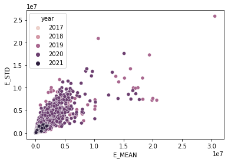

```python
sns.scatterplot(data=MCOD, x='E_MEAN', y='E_STD', hue='year')

# 평균이 높다는 것은 평균적으로 더 틀린 값을 예측
# 표준편차가 높다는 것은 예측값이 중구난방
```

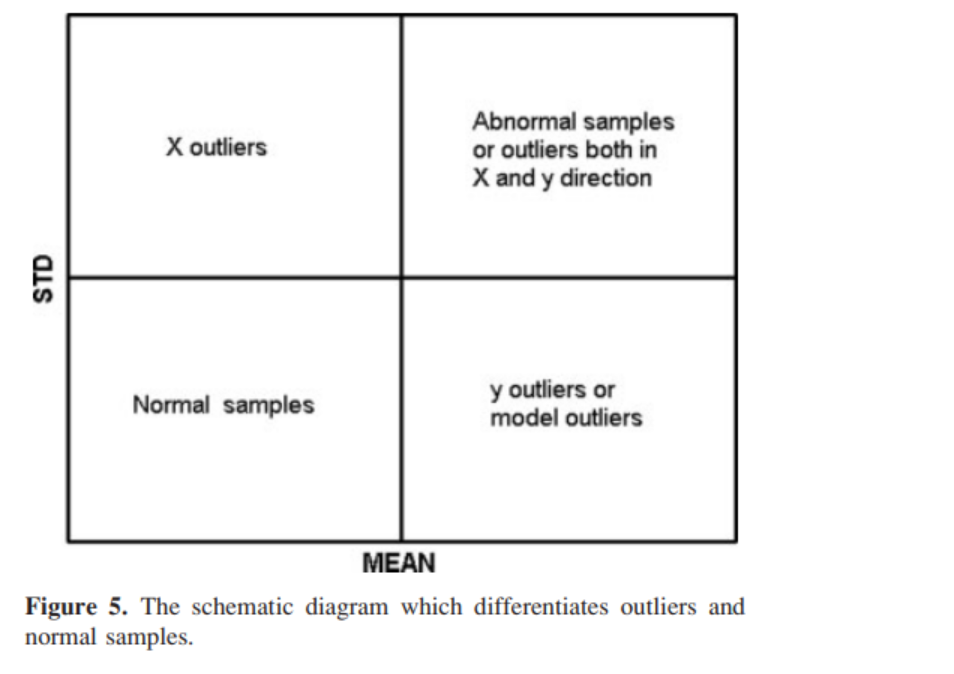

- Normal Samples: 오차 평균이 낮고, 오차 표준편차도 낮음
- y outliers: 일관성 있게 틀린 값을 이야기 함
- x outliers: feature가 이상한 것 같다는 의미
- X and y direction: 데이터가 이상하다는 의미

## Sensor 데이터 이해 및 처리

- 출처: https://ti.arc.nasa.gov/tech/dash/groups/pcoe/prognostic-data-repository/
- prognostics 라는 도메인을 대상으로 진행
- 생소한 분야를 접했을 때 헤쳐나갈 수 있는 방법 이해

```python
df = pd.read_csv('test2.csv')
df.shape
```

```
(20631, 26)
```

```python
df.head().T
```

|  | 0 | 1 | 2 | 3 | 4 |
| --- | --- | --- | --- | --- | --- |
| unit | 1.0000 | 1.0000 | 1.0000 | 1.0000 | 1.0000 |
| cycle | 1.0000 | 2.0000 | 3.0000 | 4.0000 | 5.0000 |
| op_1 | -0.0007 | 0.0019 | -0.0043 | 0.0007 | -0.0019 |
| op_2 | -0.0004 | -0.0003 | 0.0003 | 0.0000 | -0.0002 |
| op_3 | 100.0000 | 100.0000 | 100.0000 | 100.0000 | 100.0000 |
| T2 | 518.6700 | 518.6700 | 518.6700 | 518.6700 | 518.6700 |
| T24 | 641.8200 | 642.1500 | 642.3500 | 642.3500 | 642.3700 |
| T30 | 1589.7000 | 1591.8200 | 1587.9900 | 1582.7900 | 1582.8500 |
| T50 | 1400.6000 | 1403.1400 | 1404.2000 | 1401.8700 | 1406.2200 |
| P2 | 14.6200 | 14.6200 | 14.6200 | 14.6200 | 14.6200 |
| P15 | 21.6100 | 21.6100 | 21.6100 | 21.6100 | 21.6100 |
| P30 | 554.3600 | 553.7500 | 554.2600 | 554.4500 | 554.0000 |
| Nf | 2388.0600 | 2388.0400 | 2388.0800 | 2388.1100 | 2388.0600 |
| Nc | 9046.1900 | 9044.0700 | 9052.9400 | 9049.4800 | 9055.1500 |
| epr | 1.3000 | 1.3000 | 1.3000 | 1.3000 | 1.3000 |
| Ps30 | 47.4700 | 47.4900 | 47.2700 | 47.1300 | 47.2800 |
| phi | 521.6600 | 522.2800 | 522.4200 | 522.8600 | 522.1900 |
| NRf | 2388.0200 | 2388.0700 | 2388.0300 | 2388.0800 | 2388.0400 |
| NRc | 8138.6200 | 8131.4900 | 8133.2300 | 8133.8300 | 8133.8000 |
| BPR | 8.4195 | 8.4318 | 8.4178 | 8.3682 | 8.4294 |
| farB | 0.0300 | 0.0300 | 0.0300 | 0.0300 | 0.0300 |
| htBleed | 392.0000 | 392.0000 | 390.0000 | 392.0000 | 393.0000 |
| Nf_dmd | 2388.0000 | 2388.0000 | 2388.0000 | 2388.0000 | 2388.0000 |
| PCNfR_dmd | 100.0000 | 100.0000 | 100.0000 | 100.0000 | 100.0000 |
| W31 | 39.0600 | 39.0000 | 38.9500 | 38.8800 | 38.9000 |
| W32 | 23.4190 | 23.4236 | 23.3442 | 23.3739 | 23.4044 |

## Business Understanding

#### 2차 산업군에서 원하는 것은? smart factory

- VM, APC, PHM -> 모두 인공지능을 활용

#### 2차 산업군 대상으로 학습하는 이유

- SK하이닉스(이천), LG Display(파주), 현대차(울산)
- 글로벌 성공한 우리나라 그룹사들(삼성, LG, 현대, ...)
- 연습용으로 3차 산업군이 굉장히 많고, 3차 산업군은 Business Understanding이 어느정도 되어 있는 경우에서 시작함

#### VM(Virtual Metorolgy)

- 실제 측정 대신 가상으로 측정, soft-sensor라고 함
- 공정이 잘 되었는지 확인하는 과정을 계측이라 함
- 공정설비 안에서 일어나는 일들을 sensor로 데이터(feature)를 획득
- 공정 이후 계측 단계에서 결과 데이터(label) 획득

#### 가상계측의 목적

- 생산에 필요한 소요시간 감소 -> 생산성 증가
- 계측 설비 대신 ML의 지도학습으로 계측값을 도출하면 계측할 필요 없어짐 -> 계측 설비에 들어가는 비용과 시간을 줄일 수 있음
- 공정 설비에서 나오는 센서 데이터만 가지고도 어떤 계측값이 나올지 예측할 수 있다는 것

#### APC

- Automatic Process Control, 자동 공정 관리

#### 생산성에 어떻게 도움이 될까?

- 불량률을 줄일 수 있음
- 같은 시간에 같은 양을 소요 했음에도 불량률이 줄어듬으로써 생산량이 증가

#### PHM

- Prognostics and Health Management
- Prognostics(예후, 검진): 예방, 보전의 개념
- Diagnostics(진단): 증상이 있고 그것이 무엇인지 원인을 찾아나가는 것, 보통 엔지니어들이 하는 업무
- Health Management: 기계의 건강을 관리하는 것
- PHM(설비 예방보전): 고장나기 전에 미리 알고자 함
- 비행기 날개에 달렸는 있는 엔진(turbofan engine)

#### 설비 고장(down)시 해결절차 프로세스

1. 현장 엔지니어 인지
2. 담당 엔지니어 호출
3. 담당 엔지니어 입실
4. Diagnostics
5. Troubleshooting
   1. 국내에 재고가 있는 경우(부품 교체의 경우)
   2. 국내에 재고가 없는 경우(부품 교체의 경우)

#### PHM에서 궁금해하는 점

- 언제 고장날까?
- 어떤 원인의 의해서 고장날까?

#### PHM은 어떻게 생산성에 도움이 될까요?

- 설비가 동작중이다가 고장날텐데 고장 시점과 원인을 빠르게 예측하면 예방, 진단을 함으로써 생산성을 증가시킴

## Data Understanding

- unit, cycle, op_noX 센서 데이터가 아니고, T2부터의 컬럼이 sensor들임
- 생소한 데이터를 가지고 분석할 때는 컬럼의 의미를 부여하지 않아도 됨(각 컬럼별로 무엇인지 확인하는 단계는 skip 함)
- Column명이 익명화 처리되어 있는 경우가 있음 -> 문장을 도출하는 것은 동일하기 때문에 컬럼에 의미를 부여하지 않고, 나중에 문장에서 컬럼이 어떤 것인지 단어만 치환해서 표현
- Domain이 무엇인지는 Business Understanding에서 필요한데, 기계적인 프로세스는 각 컬럼이 어떤 의미를 가지는지 몰라도 됨
- 컬럼의 의미를 모르더라도 어떤 절차를 거쳐서 진행할 수 있는 방법을 학습하자

```python
# pandas-profiling
```

#### Sensor 데이터의 특징

- 무의미한 컬럼이 존재할 가능성이 있다.
- 표준편차가 0에 가까울 경우 필터 방식으로 제거